# Multi-site fMRI analysis using privacy-preserving federated learning and domain adaptation: ABIDE results - ScienceDirect

## Outline

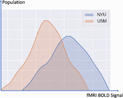

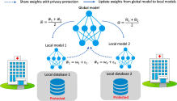

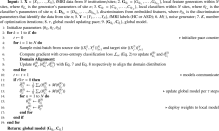

## [Medical Image Analysis](https://www.sciencedirect.com/science/journal/13618415)

[Volume 65](https://www.sciencedirect.com/science/journal/13618415/65/supp/C), October 2020, 101765

# Multi-site fMRI analysis using privacy-preserving federated learning and domain adaptation: ABIDE results

[XiaoxiaoLi<sup>a</sup>](https://www.sciencedirect.com/science/article/pii/S1361841520301298#!)[YufengGu<sup>1</sup><sup>2</sup><sup>b</sup>](https://www.sciencedirect.com/science/article/pii/S1361841520301298#!)[NichaDvornek<sup>2</sup><sup>a</sup><sup>c</sup>](https://www.sciencedirect.com/science/article/pii/S1361841520301298#!)[Lawrence H.Staib<sup>a</sup><sup>c</sup><sup>e</sup>](https://www.sciencedirect.com/science/article/pii/S1361841520301298#!)[PamelaVentola<sup>d</sup>](https://www.sciencedirect.com/science/article/pii/S1361841520301298#!)[James S.Duncan<sup>a</sup><sup>c</sup><sup>e</sup><sup>f</sup>](https://www.sciencedirect.com/science/article/pii/S1361841520301298#!)

https://doi.org/10.1016/j.media.2020.101765[Get rights and content](https://s100.copyright.com/AppDispatchServlet?publisherName=ELS&contentID=S1361841520301298&orderBeanReset=true)

Under a Creative Commons [license](https://creativecommons.org/licenses/by-nc-nd/4.0/)

open access

## Highlights

**•**

A novel framework for multi-site fMRI analysis without data-sharing using privacy-preserving federated learning.

**•**

The first employment of domain adaptation techniques on federated learning formulation for medical image analysis.

**•**

Comparisons to baseline strategies and innovative model evaluation methods from the biomarker interpretation perspective.

**•**

New insights into utilizing multi-site medical data to improve both tasks performance and replicable and informative biomarker detection.

**•**

Potential solution to training deep learning models on multiple small, heterogeneous, privacy-sensitive medical datasets.

## Abstract

Deep learning models have shown their advantage in many different tasks, including neuroimage analysis. However, to effectively train a high-quality deep learning model, the aggregation of a significant amount of patient information is required. The time and cost for acquisition and annotation in assembling, for example, large fMRI datasets make it difficult to acquire large numbers at a single site. However, due to the need to protect the privacy of patient data, it is hard to assemble a central database from multiple institutions. Federated learning allows for population-level models to be trained without centralizing entities’ data by transmitting the global model to local entities, training the model locally, and then averaging the gradients or weights in the global model. However, some studies suggest that private information can be recovered from the model gradients or weights. In this work, we address the problem of multi-site fMRI classification with a privacy-preserving strategy. To solve the problem, we propose a federated learning approach, where a decentralized iterative optimization algorithm is implemented and shared local model weights are altered by a randomization mechanism. Considering the systemic differences of fMRI distributions from different sites, we further propose two domain adaptation methods in this federated learning formulation. We investigate various practical aspects of federated model optimization and compare federated learning with alternative training strategies. Overall, our results demonstrate that it is promising to utilize multi-site data without data sharing to boost neuroimage analysis performance and find reliable disease-related biomarkers. Our proposed pipeline can be generalized to other privacy-sensitive medical data analysis problems. Our code is publicly available at: https://github.com/xxlya/Fed_ABIDE/.

## Graphical abstract

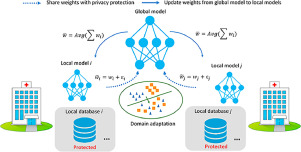

## Keywords

Federated learning

Domain adaptation

Data sharing

Privacy

Rs-fmri

ABIDE

## 1. Introduction

Data has “non-rivalrous” value, a term from the economics literature (Weimer and Vining, 2017), meaning that it can be utilized by multiple parties at a time to create additional data products or services. Pooling data together will have synergistic effects. For example, for developing a deep neural network for image recognition tasks, a vast training set is needed that captures the complexity of the problem (in some cases as many as ten thousand images). However, similar data at scale tend not to be available in healthcare, resulting in a lack of generalizability and accuracy for models and concerns regarding the reproducibility of results. Sharing large amounts of medical data is essential for precision medicine, with one important example being functional MRI (fMRI) data related to certain neurological diseases or disorders. The time and cost for acquisition and annotation in gathering large fMRI datasets make it difficult to recruit large numbers at a single site. Deep learning models have shown their advantage in fMRI analysis (Suk, Wee, Lee, Shen, 2016, Shen, Wu, Suk, 2017). Without assembling data from a number of different locations, the typically limited amount of data available from a single site becomes an obstacle to building an accurate deep learning model for neuroimage analysis.

However, there are many concerns regarding medical data sharing. For example, patients might be concerned about sharing their medical data, due to the risk that it will be shared with employers or used for future health insurance decision-making if their data are stored and accessed by multiple users, even when deidentified (Roski et al., 2014). There are questions about whether deidentified data are truly anonymous. From a legal point of view, data sharing is regulated by different federal and state laws. The power of regulation might vary due to the content of the data, its identifiability, and the context of its use (Rosenbaum and Painter, 2005). Many governmental agencies have their own privacy and data-sharing policies (POLICY et al., 2003). In addition, health systems are concerned that competitors will be able to use their data when they compete for customers. Providers worry that if their health statistics are publicly available, they will lose patients or be sanctioned if they cannot assess their performance (Heitmueller et al., 2014).

To tackle the data-sharing problem, *Federated learning* (Li et al., 2019a) was introduced to protect privacy by using training data distributed among multiple parties. Instead of transferring data directly to a centralized data warehouse for building machine learning models, in a federated learning setup, each party retains its data and performs decentralized computing. Hence, federated learning addresses privacy concerns and encourages multi-institution collaboration.

Another problem existing in utilizing data from different parties is domain shift. Diverse domains of data are common because institutions can have very different methods of data generation and collection. The scanners used in different institutions may be from different manufacturers, may be calibrated differently and may have different acquisition protocols specified. For example, in data from the Autism Brain Imaging Data Exchange (ABIDE I) (Di Martino et al., 2014), the University of Utah School of Medicine (USM) site used a 3T Siemens TrioTim MR scanner, the New York University (NYU) site used a 3T Siemens Allegra MR scanner, while the University of Michigan (UM) site used a 3T GE Signa MR scanner. Also, the instructions given to each subject were different at different sites. The USM site told participants to ”Keep your eyes open and remain awake, letting thoughts pass through your mind without focusing on any particular mental activity” while participants at the UM site looked at a fixation cross in the middle of the screen and participants at the NYU site were asked to look at a white cross-hair against a black background that was projected on a screen but some participants’ eyes were closed during scanning. Fig. 1 shows the heterogeneous fMRI data distribution of NYU and USM sites, although both of the sites used the scanners from the same manufacturer. One of the challenges of imaging studies of brain disorders is to detect robust findings across sites.Recent studies (Yao, Zhang, Li, Ye, 2019, Wang, Yu, Dunlap, Ma, Wang, Mirhoseini, Darrell, Gonzalez, 2018) have shown promising results of utilizing domain adaptation techniques to assist heterogeneous data analysis, including the applications in medical image analysis areas (Chen, Dou, Chen, Qin, Heng, 2019, Yang, Dvornek, Zhang, Chapiro, Lin, Duncan, 2019). Therefore, federated learning, together with domain adaptation methods, has the potential to extract reliable, robust neural patterns from brain imaging data of patients having different psychiatric disorders.

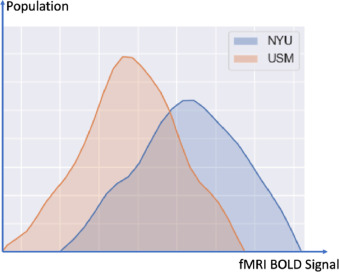

1. [Download : Download high-res image (120KB)](https://ars.els-cdn.com/content/image/1-s2.0-S1361841520301298-gr1_lrg.jpg)
2. [Download : Download full-size image](https://ars.els-cdn.com/content/image/1-s2.0-S1361841520301298-gr1.jpg)

Fig. 1. fMRI distribution of different sites.

**Our contributions** are summarized as follows:

**1.**

We formulate a new privacy-preserving pipeline for multi-site fMRI analysis and investigate various practical aspects of the federated model’s communication frequency and privacy-preserving mechanisms.

**2.**

To the best of our knowledge, we investigate domain adaptation in federated learning for medical image analysis for the first time. Domain shift due to heterogeneous data distribution is a challenging issue when utilizing medical images from different institutions.

**3.**

We propose to evaluate performance based on the biomarkers detected by the model, in addition to direct assessment of accuracy metrics.

**Paper structure:** In Section 2, we summarize related work about federated learning and unsupervised domain adaptation, the two techniques we focus on in this paper. In Section 3, we introduce the methods used for our study. Specifically, in Section 3.1, we propose the privacy-preserving federated learning setup for multi-site fMRI analysis; in Section 3.2, we propose two domain adaptation methods to boost federated learning performance; and in Section 3.3, we propose the biomarker detection and evaluation methods. The experiments, results, and evaluation methods are presented in Section 4. We conclude the paper in Section 5.

## 2. Related work

### 2.1. Federated learning

Generally, federated learning can be achieved by two approaches: 1) each party training the model using private data and where only model parameters being transferred and 2) using encryption techniques to allow safe communications between different parties (Yang et al., 2019b). In this way, the details of the data are not disclosed in between each party. In this paper, we focus on the first approach, which has been studied in (Dean, Corrado, Monga, Chen, Devin, Mao, Ranzato, Senior, Tucker, Yang, et al., 2012, Lewis, 2020, Shokri, Shmatikov, 2015, McMahan, Moore, Ramage, Agüera y Arcas).

Obtaining sufficient data is a major challenge in the field of medical imaging. Apart from data collection, labeling medical image data that require expert knowledge can be addressed by the collaboration between institutions. However, there are lots of potential legal and technical issues when sharing medical data to a centralized location, especially among international institutions. In the medical imaging field, multi-institutional deep learning without sharing patient data was firstly investigated in (Sheller et al., 2018). Later, another work (Li et al., 2019b) empirically studied privacy-preserving issues using a sparse vector technique and investigated model weights sharing schemes for imbalanced data. We note that the randomization mechanism for privacy protection and domain adaptation issues have not been studied in federated learning for medical images. We address these two issues in our study.

### 2.2. Domain adaptation

Domain Adaptation aims to transfer the knowledge learned from a source domain to a target domain. Then, a model trained over a data set from a source domain is further refined to adapt to a data set from a different target domain. Unsupervised domain adaptation methods have been extensively studied (Gholami, Sahu, Rudovic, Bousmalis, Pavlovic, 2018, Zhao, Li, Yue, Gu, Xu, Hu, Chai, Keutzer, 2019, Hoffman, Mohri, Zhang, 2018, Long, Cao, Wang, Jordan, 2015, Ganin, Lempitsky, 2014, Tzeng, Hoffman, Saenko, Darrell, 2017, Zhu, Park, Isola, Efros, 2017, Long, Cao, Wang, Jordan, 2018). However, these efforts cannot meet the requirements of federated settings: data are stored locally and cannot be shared, which hinders adaptive approaches in mainstream domains because they require access to source and target data (Tzeng, Hoffman, Zhang, Saenko, Darrell, 2014, Long, Zhu, Wang, Jordan, 2017, Ghifary, Kleijn, Zhang, Balduzzi, Li, 2016, Sun, Saenko, 2016, Ganin, Lempitsky, 2014, Tzeng, Hoffman, Saenko, Darrell, 2017). Federated domain adaptation has been recently proposed (Peng, Huang, Zhu, Saenko, 2019, Peterson, Kanani, Marathe, 2019). In our study, we investigate adopting those two federated domain adaptation methods in our multi-source and multi-target federated learning domain adaptation problem.

## 3. Methods

### 3.1. Basic privacy-preserving federated learning setup

In this section, we formulate multi-site fMRI analysis without data sharing in a federated learning framework. Then we introduce the randomized mechanism for privacy protection. Finally, we show the details of training such a privacy-preserving federated learning network step by step.

#### 3.1.1. Problem definition

Let matrix $Di$ denote the data held by the data owner site *i*. Define *N* sites ${F1,⋯.FN},$ all of whom wish to train a deep learning model by consolidating their respective data ${D1,⋯.DN}$. For medical imaging problems, usually, the data size at each site is limited to train an accurate deep learning model. A conventional method is to put all data together and use $D=D1∪⋯∪DN$ to train a model $MMIX$. At the same time, some data sets may also contain label data. We denote the feature space as $X,$ the label space as $Y$ and we use $I$ to denote the sample ID space. The feature space $X$, label $Y$ and sample IDs $I$ constitute the complete training dataset $(I,X,Y)$. In our multi-site fMRI classification scenario: $Di$ is fMRI data, $Fi$ is the institution owning private fMRI data; $X$ is the extracted fMRI feature and label $Y$ can be the diagnosis or phenotype we want to predict. In this setting, data sets share the same feature space but are different in samples. For example, different sites have different subjects. However, the features are all fMRI signals extracted from the same preprocessing pipeline. Therefore, we can summarize the data distribution as:(1)$Xi=Xj,Yi=Yj,Ii≠Ij,∀Di,Dj,i≠j,$which belongs to the horizontal federated learning category where different data sets have large overlap on features while they have small overlap on samples (Yang et al., 2019b).

In this scenario, due to regulation and other issues, each medical institution will not share data with the other parties. A federated learning system is a learning process where the data owners collaboratively train a model $MFED,$ in which any data owner $Fi$ does not expose its data $Di$ to others. In our problem setting, assume there is a central server for computing (not for data storage). All the different medical institutions (sites) use the same deep learning architecture for the same task. Each institution trains the deep learning model in-house and updates the model weight information to a central server at a particular frequency during training. The shared weights are blurred by additive random noise ε to protect data from inverse interpretation leakage. Once the central server receives all the weights, it summarizes them and updates the new weights to each institution. The simplified pipeline is depicted in Fig. 2.

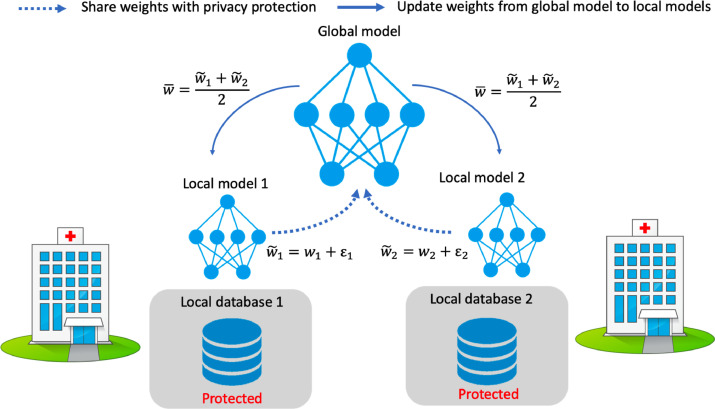

1. [Download : Download high-res image (478KB)](https://ars.els-cdn.com/content/image/1-s2.0-S1361841520301298-gr2_lrg.jpg)
2. [Download : Download full-size image](https://ars.els-cdn.com/content/image/1-s2.0-S1361841520301298-gr2.jpg)

Fig. 2. The simplified example of privacy-preserving federated learning strategy for fMRI analysis.

#### 3.1.2. Privacy-preserving decentralized training

The simplified federated learning framework is depicted in Fig. 2, which contains two key steps in decentralized optimization: 1) local update, and 2) communicating to a global server. The detailed training procedure is presented in Algorithm 1. The objective function in Algorithm 1 for training data in any site *n* is cross-entropy loss:(2)$Lcen=−∑ni[ynilog(pni)+(1−yni)log(1−pni)]$where $yni$ is the label of *i*th subject in the training label set $Yn={yn1,⋯,yn|Yn|}$ and $pni$ is the corresponding model output, which estimates the probability of that label, given an input. All the training inputs and training labels are sampled from feature space $Xn$ and label space $Yn$.

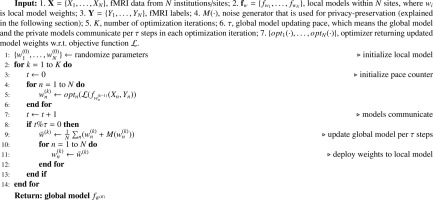

1. [Download : Download high-res image (246KB)](https://ars.els-cdn.com/content/image/1-s2.0-S1361841520301298-gr13_lrg.jpg)
2. [Download : Download full-size image](https://ars.els-cdn.com/content/image/1-s2.0-S1361841520301298-gr13.jpg)

Algorithm 1. Privacy-preserving federated learning for multi-site fMRI analysis.

#### 3.1.3. Randomized mechanism for privacy protection

Differential privacy (Dwork, Roth, et al., 2014, Dwork, McSherry, Nissim, Smith, 2006) is a popular approach to privacy-preserving machine learning (Shokri and Shmatikov, 2015) and establishes a strong standard for privacy guarantees for aggregated database-based algorithms. Informally, differential privacy aims to provide a bound, ϵ, that the attacker could learn virtually nothing more about an individual than they would learn if it were absent from the dataset as the individual’s sensitive information is almost irrelevant in the outputs of the model. The bound ϵ represents the degree of privacy preference that can be controlled by each party. A lot of research has tried to protect differential privacy at the data level when a model is learned in a centralized manner (Shokri, Shmatikov, 2015). To protect the data from inversion attack, such as inferring data from model weights, a differential privacy-preserving randomized mechanism can be incorporated into the learning process. Given a deterministic real-valued function $h:D→Rm,$ *h*’s *L*1 sensitivity *s<sub>h</sub>* is defined as the maximum of the absolute distance $∥h(D)−h(D′)∥1,$ where $∥D−D′∥1=1,$ meaning that there is only one data point difference between $D$ and $D′$(Dwork et al., 2014) (*Definition 3.1*). In our case *h* computes the *m* weight parameters in the deep learning model. Introducing “noise” in the training process (inputs, parameters, or outputs) can limit the granularity of information shared and ensure ϵ-differential privacy (Dwork et al., 2006b) (*Definition 1*) for all *S*⊆*Range*(*h*), and then (Dwork et al., 2006a):(3)$Pr[h(D)∈S]≤eϵPr[h(D′)∈S],$or(4)$Pr[h(D)∈S]≤eϵPr[h(D′)∈S]+δ,$ where the additional additive term *δ* is the probability of ϵ-differential privacy being broken. Here, we introduce two approaches: 1) Gaussian mechanism, and 2) Laplace mechanism, which can enjoy good privacy guarantees (Chaudhuri et al., 2019) by adding noise to the shared weights.

#### **Gaussian Mechanism**

The Gaussian mechanism adds $N(0,sh2σ2)$ noise with mean 0 and standard deviation *s<sub>h</sub>σ* to a function $h(D)$ with global sensitivity *s<sub>h</sub>*. $h(D)$ will satisfy (ϵ, *δ*)-differential privacy if $δ≥45exp(−(σϵ)2/2)$ and ϵ < 1 (Dwork et al., 2014) (Theorem 3.22). Hereby, we linked the Gaussian noise parameter *σ* to the privacy parameters ϵ and *δ*.

#### **Laplace Mechanism**

The Laplace Distribution centered at 0 with scale *b* is the distribution with probability density function:(5)$Lap(b):=Lap(x|b)=12exp(−|x|b),$and the variance of the Laplace distribution is $σ2=2b2$. The Laplace mechanism adds *Lap*(*s<sub>h</sub>*/ϵ) noise to a function $h(D)$ with global sensitivity *s<sub>h</sub>* and preserves (ϵ, 0)-difference privacy. Hereby, we linked the Laplace noise parameter *b* to the privacy parameters ϵ.

In our case, mapping function *h* is a deep learning model and it is not tractable to compute the sensitivity *s<sub>h</sub>*. For simplicity of discussion, sensitivity *s<sub>h</sub>* is assumed to be 1. From the mechanisms described above, we can control noise parameters to meet certain privacy requirement, as the noise parameters are linked to privacy parameters as shown above.

### 3.2. Boosting multi-site learning with domain adaptation

Although federated learning is promising for better privacy and efficiency, there is the additional issue that the data at each site likely have different distributions, leading to domain shift between the sites (Quionero-Candela et al., 2009). The main hypothesis here is that domain adaptation techniques can improve overall accuracy of different sites in a federated learning setting, and that holds even when noise is added for privacy-preservation, especially for the sites whose data distributions are quite different from the other sites. In this subsection, we investigate two domain adaptation methods: 1) Mixture of Experts (MoE), adaptation near the output layer, and 2) Adversarial domain alignment, adaptation on the data knowledge representation level.

#### 3.2.1. Mixture of experts (MoE) domain adaptation

Mixture of Experts (MoE) (Masoudnia, Ebrahimpour, 2014, Shazeer, Mirhoseini, Maziarz, Davis, Le, Hinton, Dean, 2017, Wang, Yu, Dunlap, Ma, Wang, Mirhoseini, Darrell, Gonzalez, 2018) is an approach to conditionally combine experts to process each input. In deep learning, experts mean deep learning models. An MoE layer for feed-forward neural networks is a trainable gating network that dynamically assigns gated weights to combine multiple networks. Then, all parts of the big model that contains all expert models and the MoE layer are trained jointly by back-propagation.

Mixing the outputs of a collaboratively-learned general model and a domain expert was proposed for domain adaptation (Peterson et al., 2019). Improving from the previous work (Peterson et al., 2019), we integrate randomized mechanism into MoE. Each participating party has an independent set of labeled training examples that they wish to keep private, drawn from a party-specific domain distribution. These users collaborate to build a general model for the task but maintain private, domain-adapted expert models. The final predictor is a weighted average of the outputs from the general and private models. These weights are learned using a MoE architecture (Masoudnia and Ebrahimpour, 2014), so the entire model can be trained with gradient descent. More specifically, given an input data *x* ∈ *X<sub>i</sub>*, the output of the global model is $yG=fw¯(x),$which is learned using the strategy in Algorithm 1. In the binary classification setting, the output is the model’s predicted probability for the positive class. As shown in Fig. 3a, we train another local model $fϕi$ in the meantime, which is defined as a private model. The private model can have different architecture from $fw¯$ and it does not communicate with the global model. The output of the private model is $yP=fϕi(x)$. $fϕi$ is trained using the regular deep learning setting, without including privacy-related noise.

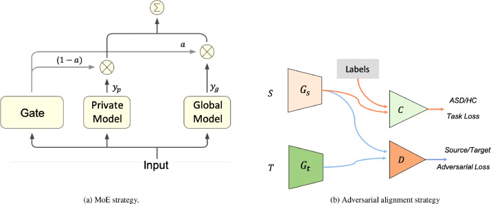

1. [Download : Download high-res image (224KB)](https://ars.els-cdn.com/content/image/1-s2.0-S1361841520301298-gr3_lrg.jpg)
2. [Download : Download full-size image](https://ars.els-cdn.com/content/image/1-s2.0-S1361841520301298-gr3.jpg)

Fig. 3. Domain adaptation strategies for our proposed federated learning setup.

The final output that entity *i* uses to label data is(6)$y^i=ai(x)yG+(1−ai(x))yP.$The weight *a<sub>i</sub>*(*x*) is called a gating function in the MoE, and we use a non-linear layer $ai(x)=σ(ψiT·x+bi)$ to compute *a<sub>i</sub>*(*x*), where *σ* is the sigmoid function, and *ψ<sub>i</sub>* and *b<sub>i</sub>* are learned weights by end-to-end training together with the federated learning architecture.

#### 3.2.2. Adversarial domain alignment

In the federated setting, the data are locally stored in a privacy-preserving manner. For the domain adaptation problem, we have multiple source domains and want to generalize the domains into a common space of target data. Due to the data sharing limitation of federated learning, we cannot train a single model that has access to the source domain and target domain simultaneously. To address this issue, we employed federated adversarial alignment (Peng et al., 2019) that introduces two modules (a domain-specific local feature extractor, and a global discriminator) in the classification networks and divides optimization into two independent steps. Using this method (Fig. 3b), for source site $Ds,$ we train a local feature extractor, *G<sub>s</sub>*. For the target site $Dt,$ we train a local feature generator *G<sub>t</sub>*. For each $(Ds,Dt)$ source-target domain pair, we train an adversarial domain discriminator *D* to align the distributions. First, domain discriminator *D* is trained to identify which domain the features come from, then the feature generators (*G<sub>s</sub>, G<sub>t</sub>*) are trained to confuse the discriminator *D*. In this setting of privacy preserving, the discriminator *D* only gets access to the output features with noise coverage of *G<sub>s</sub>* and *G<sub>t</sub>*, without leaking the original data. Specifically, the inputs of source discriminator *D* are *M*∘*G<sub>t</sub>*(*x<sup>t</sup>*) and *M*∘*G<sub>s</sub>*(*x<sup>s</sup>*), where *M*( · ) is a noise generator. Therefore, the data-leakage of target site is prevented in training the discriminator *D* on the source side. Given the source domain data **X**<sup>*S*</sup> and target data **X**<sup>*T*</sup>, the objective for discriminating the source domain from the others *D<sub>s</sub>* is defined as:(7)$LadvD(XS,XT,Gs,Gt)=−Exs∼XS[logDs(Gs(xs))]−Ext∼XT[log(1−Ds(M∘Gt(xt)))].$In the second step, *L<sub>advD</sub>* remains unchanged, but *L<sub>advG</sub>* is updated with the following objective:(8)$LadvG(XS,XT,Gs,Gt)=−Exs∼XS[logDs(Gs(xs))]−Ext∼XT[log(Ds(M∘Gt(xt))].$By end-to-end training of the federated learning model with the alignment module, we can minimize the discrepancy between the source and target domains. The implementation details are described in Algorithm 2.

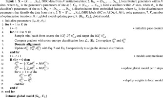

1. [Download : Download high-res image (232KB)](https://ars.els-cdn.com/content/image/1-s2.0-S1361841520301298-gr14_lrg.jpg)
2. [Download : Download full-size image](https://ars.els-cdn.com/content/image/1-s2.0-S1361841520301298-gr14.jpg)

Algorithm 2. Federated Adversarial Domain Alignment.

### 3.3. Evaluate model by interpreting biomarkers

The primary goal of psychiatric neuroimaging research is to identify objective and repeatable biomarkers that may inform the disease (Heinsfeld et al., 2018). Finding the biomarkers associated with ASD is extremely helpful in understanding the underlying roots of the disorder and can lead to earlier diagnosis and more targeted treatment. Alteration in brain functional connectivity is expected to provide potential biomarkers for classifying or predicting brain disorders (Du et al., 2018). Deep learning methods are promising tools for investigating the reliability of patterns of brain function across large and heterogeneous data sets (Varoquaux and Thirion, 2014).

We held the hypothesis that reliable biomarkers could be detected from a reliable model. The guided gradient-based explanation method (Simonyan, Vedaldi, Zisserman, Springenberg, Dosovitskiy, Brox, Riedmiller, 2014) is perhaps the most straightforward and easiest approach for data feature importance interpretation. The advantage of gradient-based explanation method is easy to compute. By calculating the difference of the output w.r.t the model input then applying norm, a score can be obtained. The gradient-based score can be used to indicate the relative importance of the input feature since it represents the change in input space, which corresponds to the positive maximizing rate of change in the model output.(9)$gkc=ReLU(∂y^c∂xk)$where $c∈{0,…,C−1}$ is the correct class of input, $C$ is the total number of classes, and *y<sup>c</sup>* is the score for class *c* before softmax layer, *x<sub>k</sub>* is the *k*th feature of the input. $gkc$ can indicate the importance of feature *k* for classifying an input as class *c*. We use this method to interpret the important features (ROIs) as biomarkers.

Given the important biomarkers, first, we propose to examine their consistency, i.e., whether the biomarkers are robust across different datasets. Second, we should examine whether the biomarkers are meaningful. For the relatively important features selected, such as the features with the top *K* important scores, we can ”decode” them to associated functional keywords based on prior knowledge and compute the correlation score $vkeywordc$ for the keyword with the biomarkers in class *c*. The informative biomarkers of the inputs in the different classes *c* should have different functional representations, which means we expect large $|Δ|=|vkeywordc−vkeywordc′|$ for the informative biomarkers, where $c′∈C∖c$. The larger the difference, the more representative and informative the biomarkers.

## 4. Experiments and results

### 4.1. Data

#### 4.1.1. Participants

The study was carried out using resting-state fMRI (rs-fMRI) data from the Autism Brain Imaging Data Exchange dataset (ABIDE I preprocessed, (Di Martino et al., 2014)). ABIDE is a consortium that provides preciously collected rs-fMRI ASD and matched controls data for the purpose of data sharing in the scientific community. However, in reality, collecting data in a consortium like ABIDE is not easy as strict agreement need to be reached by different parties. Therefore, although the data were shared in ABIDE, we studied the multi-site data from the federated learning perspective. To ensure the deep learning model could perform on a single site, we downloaded Regions of Interests (ROIs) fMRI series of the top four largest sites (UM1, NYU, USM, UCLA1) from the preprocessed ABIDE dataset with Configurable Pipeline for the Analysis of Connectomes (CPAC), band-pass filtering (0.01 - 0.1 Hz), no global signal regression, parcellated by Harvard-Oxford (HO) atlas. Skipping subjects lacking filename, we downloaded 106, 175, 72, 71 subjects from UM1, NYU, USM, UCLA1 separately. HO parcellated each brain into 111 ROIs. Since some subjects did not contain complete ROIs, we removed the incomplete data, resulting in 88, 167, 52, 63 subjects for UM1, NYU, USM, UCLA1 separately. Due to a lack of sufficient data, we used sliding windows (with window size 32 and stride 1) to truncate raw time sequences of fMRI. After removing incomplete subjects, the compositions of four sites were shown in Table 1. We denoted UM for UM1 and UCLA for UCLA1. We summarized the phenotype information of the subjects under our study in Table 2.

Table 1. Data summary of the dataset used in our study.

|  | NYU | UM | USM | UCLA |
| --- | --- | --- | --- | --- |
| Total Subject | 167 | 88 | 52 | 63 |
| ASD Subject | 73 | 43 | 33 | 37 |
| HC Subject | 94 | 45 | 19 | 26 |
| ASD Percentage | 44% | 49% | 63% | 59% |
| fMRI Frames | 176 | 296 | 236 | 116 |
| Overlapping Trunc | 145 | 265 | 205 | 85 |

Table 2. Data phenotype summary.

|  | SITE | AGE | ADOS | IQ | SEX |
| --- | --- | --- | --- | --- | --- |
| ASD | UM | 12.4(2.2) | – | 102.8(18.8) | M 36 F 7 |
|  | USM | 22.9(7.3) | 12.6(3.0) | 99.8(16.4) | M 33 F 0 |
|  | NYU | 14.7(7.1) | 11.5(4.1) | 107.4(16.5) | M 65 F 8 |
|  | UCLA | 13.0(2.7) | 10.4(3.6) | 103.5(13.5) | M 31 F 6 |
| HC | UM | 14.1(3.4) | – | 106.7(9.6) | M 32 F 13 |
|  | USM | 20.8(8.2) | – | 117.1(14.4) | M 19 F 0 |
|  | NYU | 15.2(5.9) | – | 112.6(13.5) | M 69 F 25 |
|  | UCLA | 13.4(2.3) | – | 104.9(10.4) | M 22 F 4 |

Values reported with mean (std) format. M: Male, F: Female, ADOS score: - means information not available

#### 4.1.2. Data preprocessing

The task we performed on the ABIDE datasets was to identify autism spectrum disorders (ASD) or healthy control (HC). We used the mean time sequences of ROIs to compute the correlation matrix as functional connectivity. The functional connectivity provided an index of the level of co-activation of brain regions based on the time series of rs-fMRI brain imaging data. Each element of the correlation matrix was calculated using Pearson correlation coefficient, which ranged from -1 to 1: values close to 1 indicated that the time series were highly correlated and values close to -1 indicate that the time series are anti-correlated. Then, we applied the Fisher transformation on the correlation matrices to emphasize the strong correlations. As the correlation matrices were symmetric, we only kept the upper-triangle of the matrices and flattened the triangle values to vectors, with the purpose of using them for the inputs of multilayer perceptron (MLP) classifiers. The number of resultant features was defined by $R(R−1)/2,$ where *R* was the number of ROIs. Under the HO atlas (111 ROIs), the procedure resulted in 6105 features.